# Primeros pasos en R

Los-Ignorantes

2023-03-29

## Definición de variables numéricas

Para definir variables numéricas basta con darle un nombre a la variable y poner la flecha de asignación seguida del valor numérico que queremos asignar. En la ventana superior derecha aparecerá la variable con su valor.

```r
ca <- 16
ca
```

```
## [1] 16
```

### Vectores

Los vectores son otra estructura de datos de R que a diferencia de las variables que vimos antes, aloja una colección de valores. Desde el punto de vista de objetos una variable simple es un vector que sólo tiene un elemento.

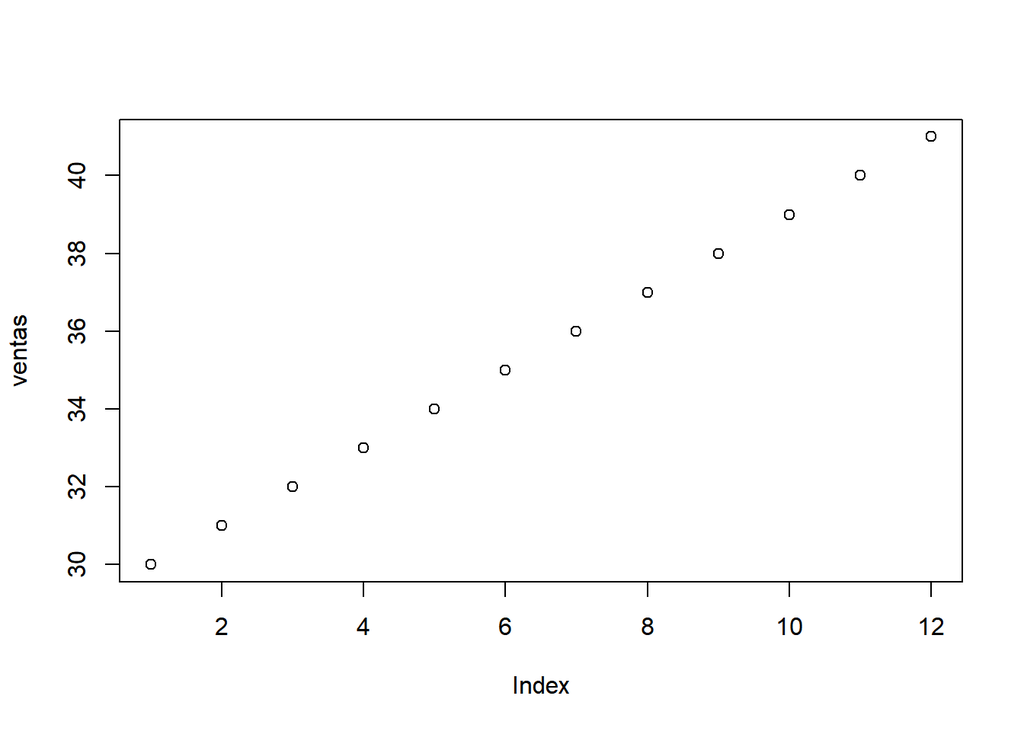

```r
ventas <- c(30,31,32,33,34,35,36,37,38,39,40,41)
plot(ventas)
```

Quisiera saber cual es el nivel promedio de ventas anuales y el desvío estándar.

```r
mean(ventas)
```

```
## [1] 35.5
```

```r
sd(ventas)
```

```
## [1] 3.605551
```

## Datos Simulados

Queremos generar unos datos para meter en un simulador que representen a nuestra empresa, vamos a generar 500 datos con el mismo promedio y desvío estándar.

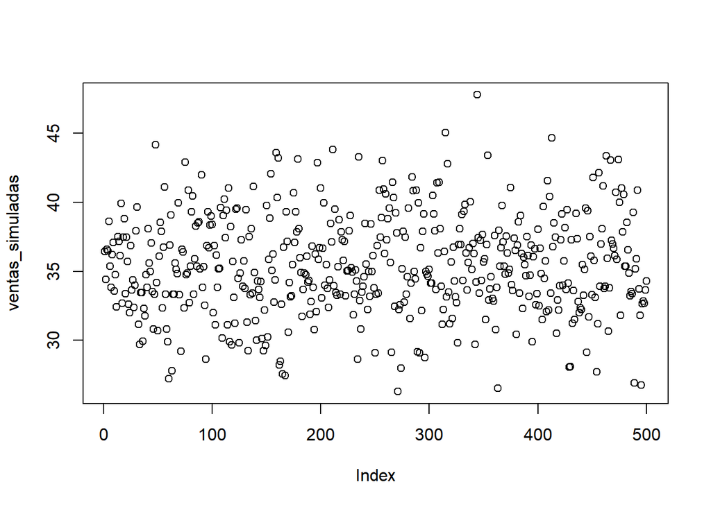

```r
ventas_simuladas <- rnorm(500,35.5,3.605551)
plot(ventas_simuladas)
```

¿Que probabilidad tengo de que las ventas sean menores a 30?

```r
pnorm(30,35.5,3.605551)
```

```
## [1] 0.06357648
```

## Variables de tipo lista

Las variables de tipo lista son vectores pero que se generan con el comando “scan()”. Como scan es un comando interactivo no podemos colocarlo dentro de un documento Rmarkdown. Sólo podemos ejecutar en la ventana de consola el comando.

```
compras <- scan()
```